# IODS course project

Minttu Lindholm

# About the project

I went to the R-courses last fall and even though it was really difficult to me and lot of hard work needed, I really got excited and now Im here again feeling very uncertain but at the same time very motivated to learn. Here is the link to my IODS project in GitHub https://github.com/madmintt/IODS-project

# REGRESSION AND MODEL VALIDATION

*This week I have learned to draw advanced scatterplots and some new things about the diagnostics of regressionmodel.*

```r
learning2014 <-read.csv("create_learning2014.csv", TRUE, ",")
summary(learning2014)
```

```
##       X.3              X.2              X.1               X
##  Min.   :  1.00   Min.   :  1.00   Min.   :  1.00   Min.   :  1.00
##  1st Qu.: 42.25   1st Qu.: 42.25   1st Qu.: 42.25   1st Qu.: 42.25
##  Median : 83.50   Median : 83.50   Median : 83.50   Median : 83.50
##  Mean   : 83.50   Mean   : 83.50   Mean   : 83.50   Mean   : 83.50
##  3rd Qu.:124.75   3rd Qu.:124.75   3rd Qu.:124.75   3rd Qu.:124.75
##  Max.   :166.00   Max.   :166.00   Max.   :166.00   Max.   :166.00
##  gender       Age           Attitude          deep            stra
##  F:110   Min.   :17.00   Min.   :1.400   Min.   :1.583   Min.   :1.250
##  M: 56   1st Qu.:21.00   1st Qu.:2.600   1st Qu.:3.333   1st Qu.:2.625
##          Median :22.00   Median :3.200   Median :3.667   Median :3.188
##          Mean   :25.51   Mean   :3.143   Mean   :3.680   Mean   :3.121
##          3rd Qu.:27.00   3rd Qu.:3.700   3rd Qu.:4.083   3rd Qu.:3.625
##          Max.   :55.00   Max.   :5.000   Max.   :4.917   Max.   :5.000
##       surf           Points
##  Min.   :1.583   Min.   : 7.00
##  1st Qu.:2.417   1st Qu.:19.00
##  Median :2.833   Median :23.00
##  Mean   :2.787   Mean   :22.72
##  3rd Qu.:3.167   3rd Qu.:27.75
##  Max.   :4.333   Max.   :33.00
```

**VISUALIZING THE DATA**

**Plot matrix of the variables**

[figure not shown]

```r
visual_d <- ggpairs(learning2014, mapping = aes(col = gender, alpha = 0.3), lower = list(combo = wrap("facethist", bins = 20)))
visual_d
```

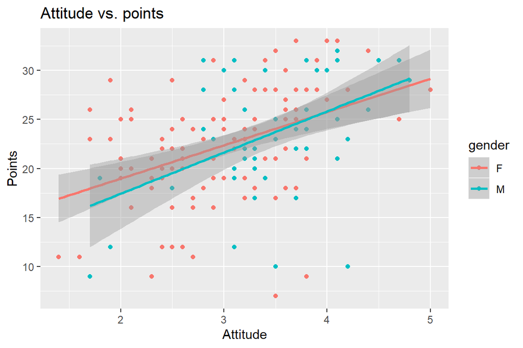

```r
pa <- ggplot(learning2014, aes(x = Attitude, y = Points, col = gender))
pat <- pa + geom_point()
patt <-pat + geom_smooth(method = "lm")
patti <-patt + ggtitle("Attitude vs. points")
patti
```

There seems to be a positive connection between attitude and points.

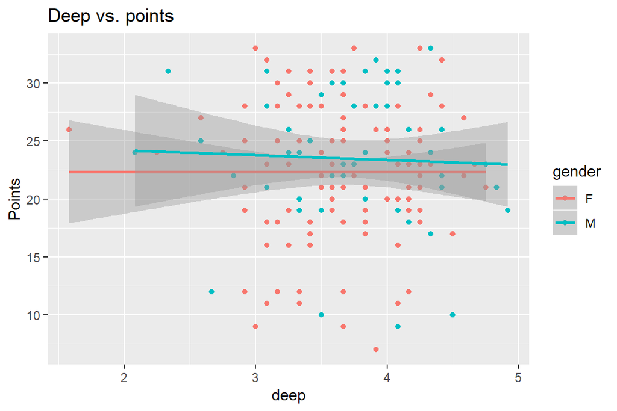

```r
pd <- ggplot(learning2014, aes(x = deep, y = Points, col = gender))
pde <- pd + geom_point()
pdee <- pde + geom_smooth(method = "lm")
pdeep <- pdee + ggtitle("Deep vs. points")
pdeep
```

There seems to be absolutely no connection between deep and points.